# 2020 Durham City and County Resident Survey

Application exercise

Suggested answers

The main question we’ll explore today is “What are the demographics and priorities of City of Durham residents?”

# Goals

- Getting familiar with survey data
- Visualizing and summarizing categorical data
- Make connections between concepts of variable types in a study and variable types in R
- Exploring relationships between categorical variables
- Improving visualizations for visual appeal and better communication

# Packages

```r
library(tidyverse)
```

# Data

The data for this case study come from the 2020 Durham City and County Resident Survey.

First, let’s load the data:

```r
durham <- read_csv("data/durham-2020.csv")
```

**Note**

Recalling the information [here](https://sta101-f24.github.io/computing/computing-file-paths.html), be prepared to adjust the file path to match how you have organized your files and folders.

# Visualizing and summarizing categorical data

## Exercise 1

How many rows and columns are in this dataset? What does each row represent and what does each column represent?

## Exercise 2

The variables we’ll use in this analysis are as follows. Rename the variables to the updated names shown below.

| Original name | Updated name |
| --- | --- |
| `primary_language` | `primary_language` |
| `do_you_own_or_rent_your_current_resi_31` | `own_rent` |
| `would_you_say_your_total_annual_hous_35` | `income` |

```r
durham <- durham |>
  rename(
    own_rent = do_you_own_or_rent_your_current_resi_31,
    income = would_you_say_your_total_annual_hous_35
  )
```

## Exercise 3

What language do Durham residents speak: `primary_language`?

> What is the primary language used in your household?

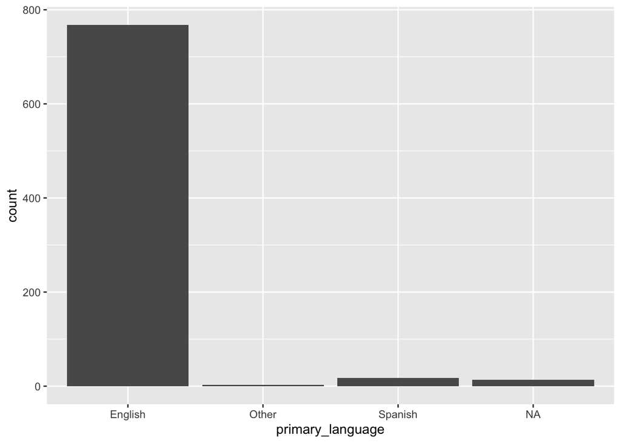

```r
ggplot(durham, aes(x = primary_language)) +
  geom_bar()
```

## Exercise 4

Make similar bar plots of `own_rent` and `income`. What distinct values do these variables take?

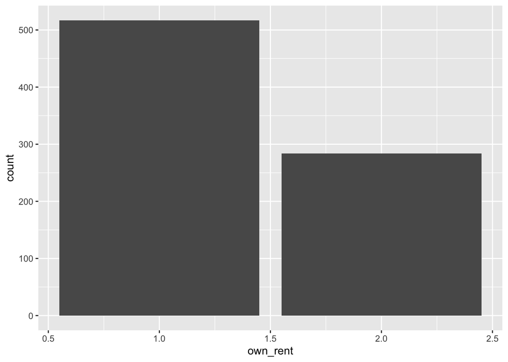

```r
ggplot(durham, aes(x = own_rent)) +
  geom_bar()
```

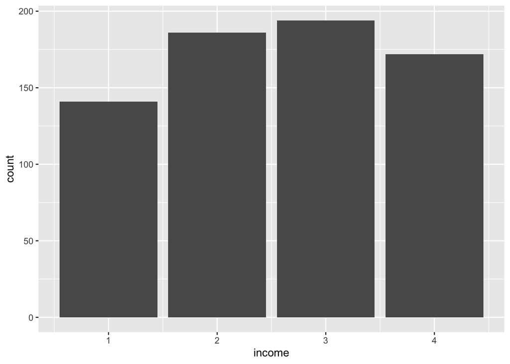

```r
ggplot(durham, aes(x = income)) +
  geom_bar()
```

## Exercise 5

The variables `own_rent` and `income` are both categorical, but they’re stored as numbers. In R, categorical data are called **factor**s. *Recode* these variables as factors with the `as_factor()` function.

```r
durham <- durham |>
  mutate(
    income = as_factor(income),
    own_rent = as_factor(own_rent)
    )
```

## Exercise 6

Recreate the visualization from the previous exercise, improving it for both visual appeal and better communication of findings.

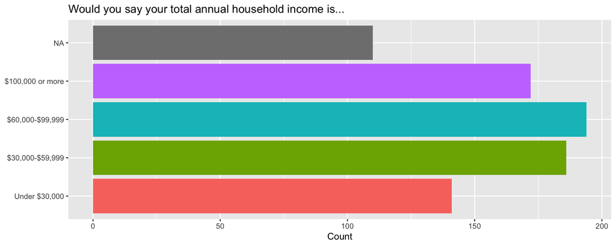

```r
durham |>
  ggplot(aes(y = income, fill = income)) +
  geom_bar(show.legend = FALSE) +
  labs(
    x = "Count",
    y = NULL,
    title = "Would you say your total annual household income is..."
  ) +
  scale_y_discrete(
    labels = c(
      "1" = "Under $30,000",
      "2" = "$30,000-$59,999",
      "3" = "$60,000-$99,999",
      "4" = "$100,000 or more"
    )
  )
```

## Exercise 7

Recreate the visualization from the previous exercise, but first calculate relative frequencies (proportions) of income (the **marginal distribution**) and plot the proportions instead of counts.

```r
my_proportions <- durham |>
  count(income) |>
  mutate(prop = n / sum(n))
```

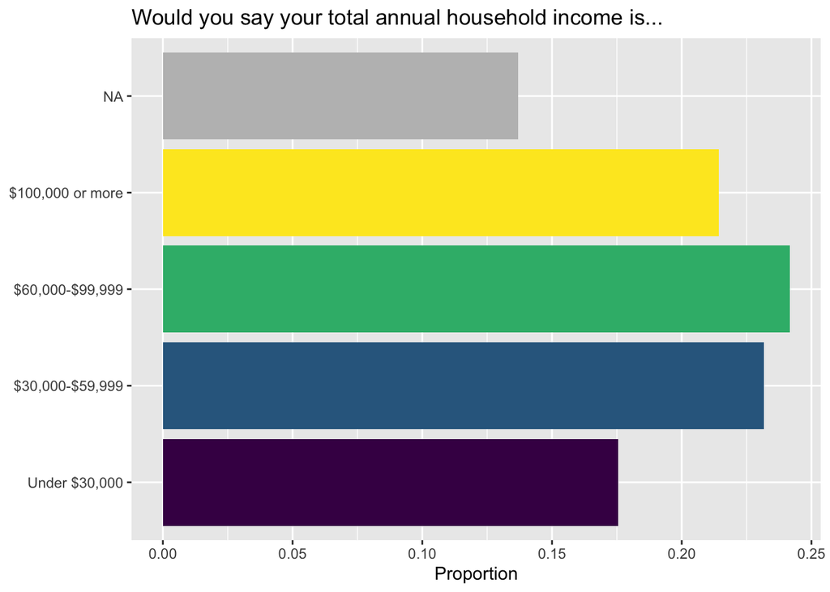

```r
ggplot(my_proportions, aes(y = income, x = prop, fill = income)) +
  geom_col(show.legend = FALSE) +
  scale_fill_viridis_d(na.value = "gray") +
  labs(
    x = "Proportion",
    y = NULL,
    title = "Would you say your total annual household income is..."
  ) +
  scale_y_discrete(
    labels = c(
      "1" = "Under $30,000",
      "2" = "$30,000-$59,999",
      "3" = "$60,000-$99,999",
      "4" = "$100,000 or more"
    )
  )
```

# Visualizing relationships

## Exercise 8

Visualize and describe the relationship between income and home ownership of Durham residents.

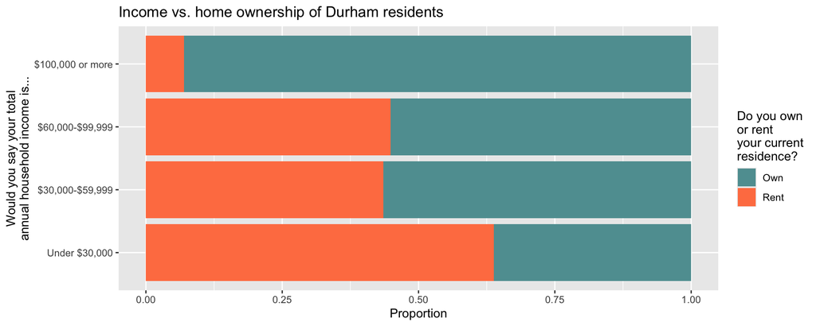

```r
durham |>
  select(income, own_rent) |>
  drop_na() |>
  ggplot(aes(y = income, fill = own_rent)) +
  geom_bar(position = "fill") +
  scale_y_discrete(
    labels = c(
      "1" = "Under $30,000",
      "2" = "$30,000-$59,999",
      "3" = "$60,000-$99,999",
      "4" = "$100,000 or more"
    )
  ) +
  scale_fill_manual(
    values = c("1" = "cadetblue", "2" = "coral"),
    labels = c("1" = "Own", "2" = "Rent")
  ) +
  labs(
    x = "Proportion",
    y = "Would you say your total\nannual household income is...",
    fill = "Do you own\nor rent\nyour current\nresidence?",
    title = "Income vs. home ownership of Durham residents"
  )
```

## Exercise 9

Calculate the proportions of home owners for each category of Durham residents. Describe the relationship between these two variables, this time with the actual values from the **conditional distribution** of home ownership based on income level.

```r
durham |>
  select(income, own_rent) |>
  drop_na() |>
  count(income, own_rent) |>
  group_by(income) |>
  mutate(prop = n / sum(n))
```

```
# A tibble: 8 × 4
# Groups:   income [4]
  income own_rent     n   prop
  <fct>  <fct>    <int>  <dbl>
1 1      1           51 0.362
2 1      2           90 0.638
3 2      1          105 0.565
4 2      2           81 0.435
5 3      1          107 0.552
6 3      2           87 0.448
7 4      1          160 0.930
8 4      2           12 0.0698
```

## Exercise 10

*Stretch goal:* Recode the **level**s of these two variables to be more informatively labeled.

```r
durham <- durham |>
  mutate(
    income = case_when(
      income == "1" ~ "Under $30,000",
      income == "2" ~ "$30,000-$59,999",
      income == "3" ~ "$60,000-$99,999",
      income == "4" ~ "$100,000 or more"
    ),
    own_rent = if_else(own_rent == 1, "Own", "Rent")
  )

durham |>
  select(income, own_rent) |>
  drop_na() |>
  count(income, own_rent) |>
  group_by(income) |>
  mutate(prop = n / sum(n))
```

```
# A tibble: 8 × 4
# Groups:   income [4]
  income           own_rent     n   prop
  <chr>            <chr>    <int>  <dbl>
1 $100,000 or more Own        160 0.930
2 $100,000 or more Rent        12 0.0698
3 $30,000-$59,999  Own        105 0.565
4 $30,000-$59,999  Rent        81 0.435
5 $60,000-$99,999  Own        107 0.552
6 $60,000-$99,999  Rent        87 0.448
7 Under $30,000    Own         51 0.362
8 Under $30,000    Rent        90 0.638
```

# Recap

## Conceptual

Some of the terms we introduced are:

- **Marginal distribution**: Distribution of a single variable.
- **Conditional distribution**: Distribution of a variable conditioned on the values (or levels, in the context of categorical data) of another.

## R

In this application exercise we:

- Defined **factor**s – the data type that R uses for categorical variables, i.e., variables that can take on values from a finite set of **level**s.
- Reviewed data imports, visualization, and wrangling functions encountered before:
  - Import: `read_csv()`: Read data from a CSV (comma separated values) file
  - Visualization:
    - `ggplot()`: Create a plot using the ggplot2 package
    - `aes()`: Map variables from the data to **aes**thetic elements of the plot, generally passed as an argument to `ggplot()` or to `geom_*()` functions (define only `x` **or** `y` aesthetic)
    - `geom_bar()`: Represent data with bars, after calculating heights of bars under the hood
    - `labs()`: Label `x` axis, `y` axis, legend for `color` of plot, title` of plot, etc.
  - Wrangling:
    - `mutate()`: Mutate the data frame by creating a new column or overwriting one of the existing columns
    - `count()`: Count the number of observations for each level of a categorical variable (factor) or each distinct value of any other type of variable
    - `group_by()`: Perform each subsequent action once per each group of the variable, where groups can be defined based on the levels of one or more variables
- Introduced new data wrangling functions:
  - `rename()`: Rename columns in a data frame
  - `as_factor()`: Convert a variable to a factor
  - `drop_na()`: Drop rows that have `NA` in one ore more specified variables
  - `if_else()`: Write logic for what happens if a condition is true and what happens if it’s not
  - `case_when()`: Write a generalized `if_else()` logic for more than one codition
- Introduced new data visualization functions:
  - `geom_col()`: Represent data with bars (**col**umns), for heights that have already been calculated (must define `x` **and** `y` aesthetics)
  - `scale_fill_viridis_d()`: Customize the **d**iscrete `fill` scale, using a color-blind friendly, ordinal **d**iscrete color scale
  - `scale_y_discrete()`: Customize the discrete `y` scale
  - `scale_fill_manual()`: Customize the `fill` scale by manually adjusting values for colors

## Quarto

We also introduced chunk options for managing figure sizes:

- `fig-width`: Width of figure
- `fig-asp`: Aspect ratio of figure (height / width)
- `fig-height`: Height of figure – but I recommend using `fig-width` and `fig-asp`, instead of `fig-width` and `fig-height`

# Acknowledgements

This dataset was cleaned and prepared for analysis by Duke StatSci PhD student [Sam Rosen](https://samgrosen.github.io/).